### 準備

```r
library(tidyverse)
set.seed(71)
```

# 集合の類似度

集合の要素を比較するための類似度としていくつかのインデックスが知られています。ここではその中でJaccard係数/Dice係数/Simpson係数をRで計算してみましょう。

cf. [【技術解説】集合の類似度(Jaccard係数，Dice係数，Simpson係数)](https://mieruca-ai.com/ai/jaccard_dice_simpson/)

- Jaccard index

$$J(A,B)=\frac{|A\cap B|}{|A \cup B|}$$

- Sørensen–Dice index

$$DSC(A,B)=\frac{2|A\cap B|}{|A| + |B|}$$

- Simpson index (Overlap coefficient)

$$overlap(A,B)=\frac{|A\cap B|}{min(|A|, |B|)}$$

## capやcupの計算

2つのベクトルを用意します。

```r
vec1 <- sample(1:80, 50)
vec2 <- sample(40:120, 50)
```

2つのベクトルの共通要素からなるベクトルを求めるには`base::intersect()`関数を用います。必要な$|A \cap B|$はその要素数なので`length()`関数でベクトルの大きさを求めます。

```r
capN <- intersect(vec1, vec2) %>% length()
```

$|A \cup B|$は和集合の重複を除いたサイズです。いくつか求め方はあると思いますが、例えば以下のようにします。

```r
cupN <- c(vec1, vec2) %>% factor() %>% levels() %>% length()
```

ここからJaccard indexは直ちに求まります。

```r
capN / cupN
```

```
## [1] 0.1627907
```

## 凝ったサンプルデータ

もう少し凝ったサンプルを作ってみましょう。

```r
dat <-
  tibble(tag = LETTERS[1:4],
         n = c(50, 40, 30, 80)) %>%
  mutate(range = list(1:80, 40:120, 70:160, c(1:50, 100:140))) %>%
  mutate(value = map2(range, n, sample)) %>%
  select(tag, value) %>%
  unnest(value)
```

```r
dat
```

```
## # A tibble: 200 × 2
##    tag   value
##    <chr> <int>
##  1 A        72
##  2 A        43
##  3 A        74
##  4 A        50
##  5 A        23
##  6 A        60
##  7 A        68
##  8 A        41
##  9 A         4
## 10 A        10
## # … with 190 more rows
```

ごちゃごちゃやっていますが、得られた`dat`オブジェクトには`tag`カラムで対応づけられた4群が含まれています。それぞれ`n`で指定された数だけ整数値を持ち、`value`カラムに格納されています。整数値は`range`で指定した範囲からランダムに重複なくサンプルされます。

データの概要は`tag`カラムをキーにしてデータを畳み込むとよく分かります。

```r
dat_nest <-
  group_nest(dat, tag)

dat_nest
```

```
## # A tibble: 4 × 2
##   tag                 data
##   <chr> <list<tibble[,1]>>
## 1 A               [50 × 1]
## 2 B               [40 × 1]
## 3 C               [30 × 1]
## 4 D               [80 × 1]
```

それぞれに畳み込まれているデータは例えば次のように取り出すことができます。

```r
dat_nest$data[[1]] %>% c()
```

```
## $value
##  [1] 72 43 74 50 23 60 68 41  4 10 28 44 73  8 53 42 49 75 67 58 77  1 25 48 47
## [26] 18 38 37 12 80 71 54 36  3  6 32 19 65 20 16  9  5 56 11 31 62 51 45 39 55
```

## 総当たり組み合わせ

さて、この4群の総当たり組み合わせでさまざまな集合の類似度を求めてみましょう。総当たり組み合わせを作るやり方は色々とありますが、僕が作った[roundrobinパッケージ](https://github.com/kilometer0101/roundrobin)が便利です。github上で公開しているので`install_github()`関数でインストールすることができます。

```r
devtools::install_github("kilometer0101/roundrobin")
```

このパッケージに含まれている`roundrobin()`関数を使うと、data.frameもしくはtibbleを指定したカラムの水準に応じてたたみ込んだのち、総当たり組み合わせを作ってくれます。畳み込む水準は`key`引数で指定しますが、文字列で指定してください。

```r
dat_rr <-
  dat %>%
  roundrobin::roundrobin(key = "tag")

dat_rr
```

```
## # A tibble: 16 × 4
##    Var1  Var2              data.x             data.y
##    <chr> <chr> <list<tibble[,1]>> <list<tibble[,1]>>
##  1 A     A               [50 × 1]           [50 × 1]
##  2 B     A               [40 × 1]           [50 × 1]
##  3 C     A               [30 × 1]           [50 × 1]
##  4 D     A               [80 × 1]           [50 × 1]
##  5 A     B               [50 × 1]           [40 × 1]
##  6 B     B               [40 × 1]           [40 × 1]
##  7 C     B               [30 × 1]           [40 × 1]
##  8 D     B               [80 × 1]           [40 × 1]
##  9 A     C               [50 × 1]           [30 × 1]
## 10 B     C               [40 × 1]           [30 × 1]
## 11 C     C               [30 × 1]           [30 × 1]
## 12 D     C               [80 × 1]           [30 × 1]
## 13 A     D               [50 × 1]           [80 × 1]
## 14 B     D               [40 × 1]           [80 × 1]
## 15 C     D               [30 × 1]           [80 × 1]
## 16 D     D               [80 × 1]           [80 × 1]
```

便利ですね！

## indexを求める

この総当たり組み合わせで畳み込まれたデータを使って効率的に様々なindexを計算してみましょう。

計算に使う$|A|+|B|$、$\min(|A|,|B|)$、$|A \cap B|$、$|A \cup B|$を準備しておきましょう。

```r
dat_for_index <-
  dat_rr %>%
  mutate(size_sum = map2_dbl(data.x, data.y, ~ nrow(.x) + nrow(.y)),
         size_min = map2_dbl(data.x, data.y, ~ min(nrow(.x), nrow(.y)))) %>%
  mutate(cap = map2_dbl(data.x, data.y, ~ intersect(.x, .y) %>% nrow()),
         cup = map2_dbl(data.x, data.y, ~ bind_rows(.x, .y) %>% distinct() %>% nrow()))

dat_for_index
```

```
## # A tibble: 16 × 8
##    Var1  Var2              data.x           data.y size_sum size_min   cap   cup
##    <chr> <chr> <list<tibble[,1]>> <list<tibble[,1>    <dbl>    <dbl> <dbl> <dbl>
##  1 A     A               [50 × 1]         [50 × 1]      100       50    50    50
##  2 B     A               [40 × 1]         [50 × 1]       90       40    12    78
##  3 C     A               [30 × 1]         [50 × 1]       80       30     5    75
##  4 D     A               [80 × 1]         [50 × 1]      130       50    26   104
##  5 A     B               [50 × 1]         [40 × 1]       90       40    12    78
##  6 B     B               [40 × 1]         [40 × 1]       80       40    40    40
##  7 C     B               [30 × 1]         [40 × 1]       70       30     6    64
##  8 D     B               [80 × 1]         [40 × 1]      120       40    16   104
##  9 A     C               [50 × 1]         [30 × 1]       80       30     5    75
## 10 B     C               [40 × 1]         [30 × 1]       70       30     6    64
## 11 C     C               [30 × 1]         [30 × 1]       60       30    30    30
## 12 D     C               [80 × 1]         [30 × 1]      110       30     9   101
## 13 A     D               [50 × 1]         [80 × 1]      130       50    26   104
## 14 B     D               [40 × 1]         [80 × 1]      120       40    16   104
## 15 C     D               [30 × 1]         [80 × 1]      110       30     9   101
## 16 D     D               [80 × 1]         [80 × 1]      160       80    80    80
```

で、定義式をみながらこんな感じ。

```r
dat_index <-
  dat_for_index %>%
  mutate(Jaccard = cap / cup,
         Dice = cap * 2 / size_sum,
         Simpson = cap / size_min) %>%
  select(Var1, Var2, Jaccard, Dice, Simpson)

dat_index
```

```
## # A tibble: 16 × 5
##    Var1  Var2  Jaccard  Dice Simpson
##    <chr> <chr>   <dbl> <dbl>   <dbl>
##  1 A     A      1      1       1
##  2 B     A      0.154  0.267   0.3
##  3 C     A      0.0667 0.125   0.167
##  4 D     A      0.25   0.4     0.52
##  5 A     B      0.154  0.267   0.3
##  6 B     B      1      1       1
##  7 C     B      0.0938 0.171   0.2
##  8 D     B      0.154  0.267   0.4
##  9 A     C      0.0667 0.125   0.167
## 10 B     C      0.0938 0.171   0.2
## 11 C     C      1      1       1
## 12 D     C      0.0891 0.164   0.3
## 13 A     D      0.25   0.4     0.52
## 14 B     D      0.154  0.267   0.4
## 15 C     D      0.0891 0.164   0.3
## 16 D     D      1      1       1
```

### 可視化

可視化はどうしましょうか。heatmap風にしてみましょう。

```r
dat_g <-
  dat_index %>%
  pivot_longer(cols = !c(Var1, Var2),
               names_to = "index",
               values_to = "value")
```

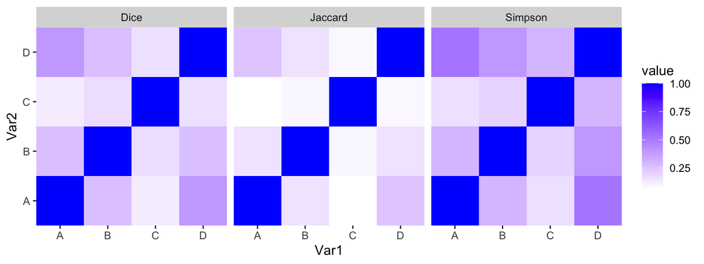

```r
ggplot(dat_g) +
  aes(Var1, Var2, fill = value) +
  geom_tile() +
  scale_fill_gradient(low = "white", high = "blue") +
  scale_x_discrete(expand = c(0,0)) +
  scale_y_discrete(expand = c(0,0)) +
  facet_wrap(~ index)
```

簡単ですね！！

2022年6月1日